# 102SVM slides

## 102 seminar

### Support Vector Machine (SVM) for classification

#### Vivek Yadav, PhD

#### Support vector machine for classification

Given data classify into different regions/groups

[figure not shown]

```python
import numpy as np
import matplotlib.pyplot as plt
import time
%pylab inline

numpy.random.seed(2016)

X1 = np.random.randn(100)+1.5
Y1 = -2*(X1)+8+2*np.random.randn(100)
X2 = np.random.randn(100)-1.5
Y2 = -2*(X2)-4 + 2*np.random.randn(100)

X_feat = np.hstack((X1,X2))
Y_feat = np.hstack((Y1,Y2))
```

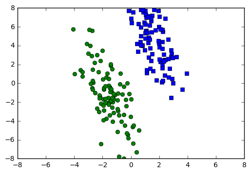

```python
plt.plot(X1,Y1,'s',X2,Y2,'o')
plt.ylim(-8,8)
plt.xlim(-8,8);
```

### Objective

- Draw a line to separate the points
- Separate so the distance between points is maximized

We wish to find (W) and (b) such that,

$$ W^Tx+b > 1 , \text{ for blue class i.e } t = 1$$$$ W^Tx+b < -1 , \text{ for green class i.e } t = -1$$

.

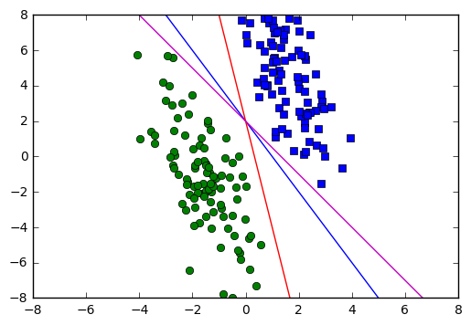

```python
X = np.linspace(-8,8,200)
Y = -2*X+2
plt.plot(X1,Y1,'s',X2,Y2,'o')
plt.plot(X,-2*X+2,'b',
         X,-6*X+2,'r',
        X,-1.5*X+2,'m')
plt.ylim(-8,8)
plt.xlim(-8,8);
```

```
(-8, 8)
```

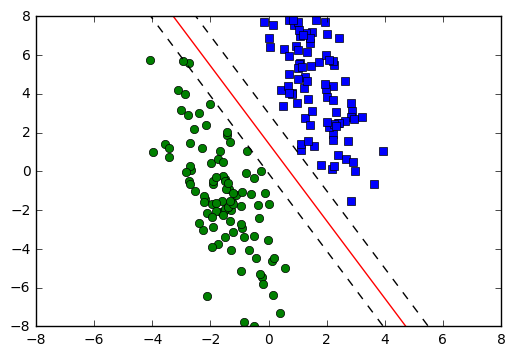

```python
### Convert as follows
X = np.linspace(-8,8,200)
Y = -2*X+2
plt.plot(X1,Y1,'s',X2,Y2,'o')
plt.plot(X,-2*X+1.45,'r',X,-2*X+3,'--k',X,-2*X-.1,'--k')
plt.ylim(-8,8)
plt.xlim(-8,8)
```

### Margin

The distance between the two lines \( W^T X = b_1 \) and \( W^T X = b_2 \) is given by \( (b_1 - b_2)/ W \), therefore the margin is

$$ margin = \frac{2}{||W||} $$

.

Maximizing margin is equivalent to minimizing \( ||W|| \), with the constraint that the points are separated, i.e.

$$ t_i (W^Tx_i+b) \geq 1,$$

for each \( i \in \) training data.

### SVM with soft margins

Add a soft margin \( \xi \) is introduced,

$$ t_i (W^Tx_i+b) > 1 - \xi_i,$$

where \( \xi_i \geq 0 \) is a slack variable that quantifies deviation from the margin lines.

- If \( \xi_i <1 \), the point is within the two black dashed lines, i.e. within the margin.
- If \( \xi_i \geq 1 \), then the point is misclassified.

The cost function now becomes,

$$ J(W) = \text{ minimize } ||W||^2 + C \sum_{i=1}^N \xi_i \text{, subject to } $$

$$ t_i (W^Tx_i+b) \geq 1 - \xi_i \text{ and } \xi_i \geq 0\text{ for each i. } $$

Here, \( ||W||^2 \) is the sum of squares of each element in \( W \).

C is a regularization parameter:

- small C allows constraints to be easily ignored i.e. large margin
- large C makes constraints hard to ignore i.e. narrow margin
- \( C = \infty \) enforces all constraints: hard margin

The cost-function above can be rewritten as, $$ J(W) = \text{ minimize } ||W||^2 + C \sum_{i=1}^N max( 0 , 1 - t_i (W^Tx_i+b)) $$

The condition above assures that \( \xi_i \geq 0 \).

Rewritte cost as,

$$ J(W) = \text{ minimize } \frac{\lambda}{2} ||W||^2 + \sum_{i=1}^N \delta_i \left( 1 - t_i W^Tx_i \right) $$

where \( \delta_i = 0 \) if \(i^{th} \) point is classified correctly, else \( \delta_i = 1 \), and \( \lambda = 2/C \).

Taking derivative of the cost gives,

$$ \frac{\partial J }{ \partial W } = \lambda W - \sum_{i=1}^N \delta_i t_i x_i $$

```python
def plot_fig(W):
    plt.plot(X1,Y1,'s',X2,Y2,'o')
    plt.plot(X,(-W[0]*X-W[2])/W[1])
    plt.plot(X,(-W[0]*X-W[2]+1)/W[1],'k--')
    plt.plot(X,(-W[0]*X-W[2]-1)/W[1],'k--')
    plt.ylim(-8,8)
    plt.xlim(-8,8)
```

```python
def svm_weights(X_mod,target,W,
                lam,lr,plot_option):
    i_plot = 0
    for i_loop in np.arange(0,1000):
        pred_fun  = np.dot(X_mod,W)
        pred_fun[pred_fun>=1] = 1
        pred_fun[pred_fun<=-1] = -1
        delta_index = [i for i in np.arange(0,len(target)) if target[i] == pred_fun[i]]
        delta= np.ones(np.shape(target))
        delta[delta_index]= 0
        W_mis = np.dot(np.multiply(delta,target),X_mod)
        djdW = np.multiply(lam,W) - W_mis
        W += -lr*djdW
    return W
```

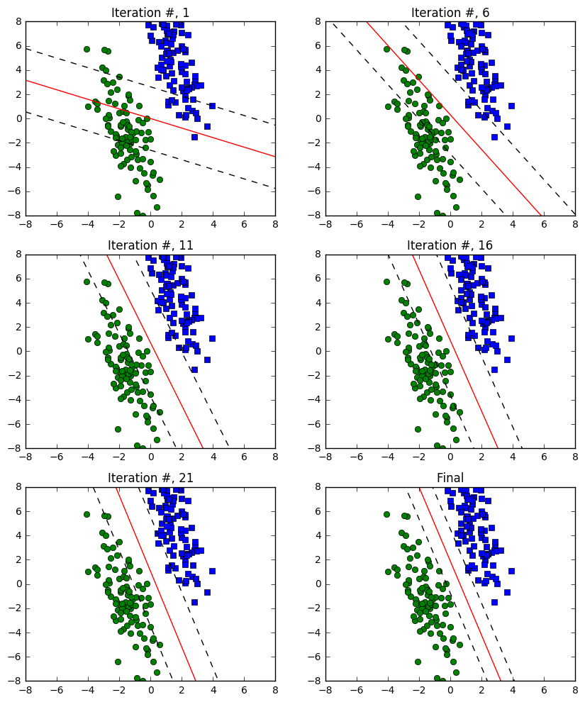

```python
W = [0,0.1,0]
lam = .1
lr = 0.0005
i_plot = 0

x_cord  = np.hstack((X1, X2)).T
y_cord  = np.hstack((Y1, Y2)).T
X_mod = np.vstack((x_cord,y_cord,np.ones(np.shape(x_cord)))).T
target = np.hstack((np.ones(np.shape(X1)),-np.ones(np.shape(X2))))

plt.figure(figsize = (10,12))
plot_option = 1
for i_loop in np.arange(0,1000):
    # Predict function
    pred_fun  = np.dot(X_mod,W)
    pred_fun[pred_fun>=1] = 1
    pred_fun[pred_fun<=-1] = -1

    # delta function
    delta_index = [i for i in np.arange(0,len(target)) if target[i] == pred_fun[i]]
    delta= np.ones(np.shape(target))
    delta[delta_index]= 0

    # dJdW for misclassified points
    dJdW_mis = np.dot(np.multiply(delta,target),X_mod)
    # This is second term of the derivative, due to misclassification
    djdW = np.multiply(lam,W) - dJdW_mis
    W += -lr*djdW
    if ((i_loop%5==0) & (i_loop<25) & (plot_option == 1)):
        #print i_loop
        i_plot +=1
        plt.subplot(3,2,i_plot)
        plot_fig(W)
        title_str = 'Iteration #, %d'%(i_loop+1)
        plt.title(title_str)
    #W += -lr*djdW

plt.subplot(3,2,6)
plot_fig(W)
plt.title('Final')
```

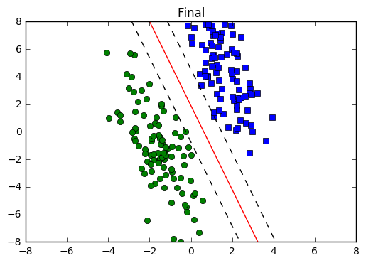

```python
plot_fig(W)
plt.title('Final');
```

### Solve the same above using SKLearn

- Sklearn wrapper around linear and nonlinear SVM
- Easy to implement
- Needn't go through complex math for SVM

http://scikit-learn.org/stable/modules/generated/sklearn.svm.SVC.html

```python
from sklearn.svm import SVC

labels = np.zeros(200)
labels[100:]=1

features = [[X_feat[i],Y_feat[i]] for i in range(len(labels))]

clf = SVC(kernel = 'linear')
clf.fit(features,labels)
```

```
SVC(C=1.0, cache_size=200, class_weight=None, coef0=0.0,
  decision_function_shape=None, degree=3, gamma='auto', kernel='linear',
  max_iter=-1, probability=False, random_state=None, shrinking=True,
  tol=0.001, verbose=False)
```

```python
w = clf.coef_[0]
a = -w[0] / w[1]
xx = np.linspace(-10, 10)
yy = a * xx - (clf.intercept_[0]) / w[1]

# plot the parallels to the separating hyperplane that pass through the
# support vectors
margin = 1 / np.sqrt(np.sum(clf.coef_ ** 2))
Y_down = yy + a * margin
Y_up = yy - a * margin

# plot the line, the points, and the nearest vectors to the plane
```

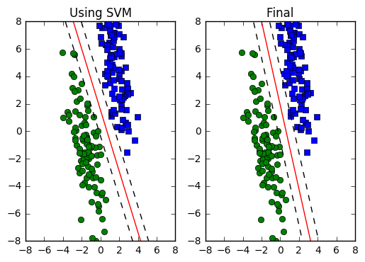

```python
plt.subplot(1,2,1)
plt.plot(X1,Y1,'s',X2,Y2,'o')
plt.plot(xx, yy, 'r')
plt.plot(xx, Y_down, 'k--')
plt.plot(xx, Y_up, 'k--')
plt.ylim(-8,8)
plt.xlim(-8,8);
plt.title('Using SVM');
plt.subplot(1,2,2)
plot_fig(W)
plt.title('Final');
```

```python
###
```